# title

Taiguara Melo Tupinambas

Entrega: 06 de maio de 2017

# Exercício 1

O valor esperado de $X_i$, $E[X_i]=\frac{1}{2}-\frac{1}{2}=0$

Logo, o valor esperado de $Y_N$ é temos que:

$$\begin{gather}
Y_N=\sum_{i=1}^N\frac{X_i}{\sqrt{N}}\\
E[Y_N]=E[\sum_{i=1}^N\frac{X_i}{\sqrt{N}}]=\frac{1}{\sqrt(N)}NE[X]\\
E[Y_N]=0
\end{gather}$$

A variância de $X_i$, $var(X_I)=E[X^2]-E^2[X]=E[X^2]$ e como $E[X^2]=\frac{1}{2}+\frac{1}{2}=1$, temos que a variância de $Y_N$ é dada por:

$$\begin{gather}
var(Y_N)=var(\frac{1}{\sqrt{N}}\sum_{i=1}^NX_i)=\frac{1}{N}\sum_{i=1}^Nvar(X_i)=var(X)\\
var(Y_N)=1
\end{gather}$$

Logo, pelo teorema do limite central, $Y_N \sim N(0,1)$. Realizando a simulação, os resultados encontrados foram coerentes.

```r
set.seed(1)

N<-1000
n<-1000
y<-matrix(0,N)

for (i in 1:N) {
        for (j in 1:n) {
                if (runif(1)<0.5) {
                        x<-1
                } else {
                        x<--1
                }
                y[i]<-y[i]+x
        }
}

y<-y/sqrt(n)

cat("Média = ", mean(y), "Varância =", var(y))
```

```
## Média =  -0.02340085 Varância = 1.007116
```

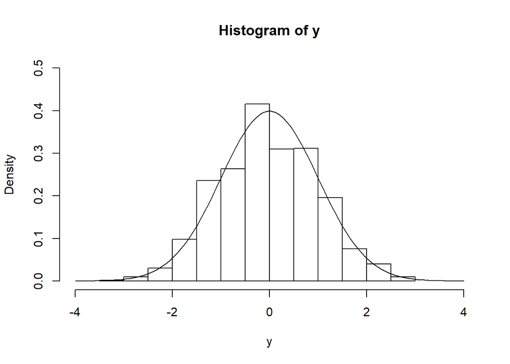

```r
x<-seq(-4,4,length=100)
distx<-dnorm(x)

hist(y,freq = F,xlim=c(-4,4),ylim=c(0,0.5))
lines(x,distx)
```

# Exercício 2

Para uma sequência de VAs independentes de Bernoulli dadas por:

$$p_X(X_i)=\begin{cases}
p, \ \ X_i=1\\
1-p, \ \ X_i=0
\end{cases}$$

Desta forma, o estimador de p pode ser definido como $p=E[Y_N]$, em que $Y_N=\frac{1}{N}\sum_{i=1}^N X_i$ e a variância de $Y_N$ é igual a $\frac{p(1-p)}{N}$.

Pela desigualdade de Chebyshev, temos que:

$$\begin{gather}
P(|\hat Y_N - E[Y_N]|>\epsilon)\leq \frac{var(Y_N)}{\epsilon^2}\\
P(|\hat p - p|>\epsilon)\leq \frac{p(1-p)}{N\epsilon^2}
\end{gather}$$

A definição de um valor de $N$, tal que a probabilidade do valor estimado para $p$ ser, em módulo, menor do que 0,01, de 95%, é o mesmo que dizer:

$$\begin{gather}
P(|\hat p - p|<0.01)\geq 95\% \\\\
P(|\hat p - p|>0.01)\leq 100\%-95\%=5\% \\
\end{gather}$$

Ou seja, a última expressão seria a desigualdade de Chebyshev, com $\epsilon=0.01$, e $\frac{var(Y_N)}{\epsilon^2}=\frac{p(1-p)}{0.01^2N}=0.05$

Algumas simulaçÕes foram feitas para valroes de p iguais a 0.1 (N=18000), 0.5 (N=50000) e 0.75 (N=37500).

```r
set.seed(1)

p<-c(0.1,0.5,0.75)
N<-p*(1-p)*200000
n<-100
y<-matrix(0,length(N),n)

for (k in 1:n) {
        for (i in 1:length(N)) {
                for (j in 1:N[i]) {
                        if (runif(1)<p[i]) {
                                x<-1
                        } else {
                                x<-0
                        }
                        y[i,k]<-y[i,k]+x
                }
                y[i,k]<-y[i,k]/N[i]
        }
}


erro<-abs(p-y)
erro<-erro<0.01

prob_erro<-matrix(0,length(N),n)

for (i in 1:length(N)) {
        prob_erro[i]<-sum(erro[i,])
}

cat("Frequência de erros menores que 0.01 para p=0.1", prob_erro[1])
```

```
## Frequência de erros menores que 0.01 para p=0.1 100
```

```r
cat("\nFrequência de erros menores que 0.01 para p=0.5", prob_erro[2])
```

```
##
## Frequência de erros menores que 0.01 para p=0.5 100
```

```r
cat("\nFrequência de erros menores que 0.01 para p=0.75", prob_erro[3])
```

```
##
## Frequência de erros menores que 0.01 para p=0.75 100
```

# Exercício 4

## 15.5

$$\begin{gather}
X_N=X_{N-1}+U_N\\
X_N=U_1+U_2+...+U_N\\
X_N=\sum_{i=1}^{N}U_i\\
\end{gather}$$

Para avaliar a convergência, podemos analisar a desigualdade de Chebyshev:

$$\begin{gather}
P[|\bar{X}_N-E_X[X]|>\epsilon]\leq \frac{var(\bar{X}_N)}{\epsilon^2}
\end{gather}$$

Mas, como:

$$\begin{gather}
var(\bar{X}_N)=\sum_{i=1}^{N}var(U_i)=\sum_{i=1}^{N}\frac{(1+1)^2}{12}=\sum_{i=1}^{N}\frac{1}{3}\\
\\
\lim_{N \rightarrow \infty}var(\bar{X}_N) \rightarrow \infty
\end{gather}$$

$X_N$ não irá convergir.

# 15.6

Considerando que as variáveis $X_i$ para $i=1,2..,N$ são independentes e idênticamente distribuídas, temos que:

$$\begin{gather}
X_N=\frac{1}{N}\sum_{i=1}^NX_i^2\\
E_X[X_N^2]=\frac{1}{N}\sum_{i=1}^NE_X[X^2]=E_X[X^2]\\
\\
var(X_N^2)=E_X[X^4]-E_X^2[X^2]
\end{gather}$$

Considerando que $E_X[X_N^2]$ existe, para que o estimador convirja, é necessário que $var(X_N^2)<\infty$

## 15.7

$$\begin{gather}
X_N=\frac{1}{\sqrt{N}}\sum_{i=1}^NX_i\\
\\
var(X_N)=var(\frac{1}{\sqrt{N}}\sum_{i=1}^NX_i)=\frac{1}{N}var(\sum_{i=1}^NX_i)=var(X)
\end{gather}$$

Como $var(X)\neq 0$, para $N\rightarrow \infty$, a variável aleatória não irá convergir

## 15.8

Temos que:

$$Y_N=\begin{cases}
\frac{X_N}{\sqrt{N}}+1, \ se \ \frac{X_N}{\sqrt{N}}>0.1\\
\frac{X_N}{\sqrt{N}},\ se \ \frac{X_N}{\sqrt{N}}\leq 0.1
\end{cases}$$

Logo:

$$\begin{gather}
P[|Y_N|>\epsilon]=P[|{\frac{X_N}{\sqrt{N}}+1}|>\epsilon]P[\frac{X_N}{\sqrt{N}}>0.1]+P[|\frac{X_N}{\sqrt{N}}|>\epsilon]P[\frac{X_N}{\sqrt{N}}\leq 0.1]\\
P[|Y_N|>\epsilon]=(1-P[-\epsilon <{\frac{X_N}{\sqrt{N}}+1}<\epsilon])P[\frac{X_N}{\sqrt{N}}>0.1]+(1+P[-\epsilon<\frac{X_N}{\sqrt{N}}<\epsilon])P[\frac{X_N}{\sqrt{N}}\leq 0.1]\\
\end{gather}$$

Sabendo que:

$$\begin{gather}
\frac{X_N}{\sqrt{N}} \sim N(0,\frac{1}{\sqrt{N}})\\
\frac{X_N}{\sqrt{N}}+1 \sim N(1,\frac{1}{\sqrt{N}})
\end{gather}$$

Temos:

$$\begin{gather}
P[|Y_N|>\epsilon]=(1-[Q(\frac{-\epsilon-1}{\sqrt{\frac{1}{N}}})-Q(\frac{\epsilon-1}{\sqrt{\frac{1}{N}}})])Q(\frac{0.1}{\sqrt{\frac{1}{N}}})+
(1-[Q(\frac{-\epsilon}{\sqrt{\frac{1}{N}}})-Q(\frac{\epsilon}{\sqrt{\frac{1}{N}}})])(1-Q(\frac{0.1}{\sqrt{\frac{1}{N}}}))
\end{gather}$$

Como $\frac{1}{\sqrt{\frac{1}{N}}}=\sqrt{N}$, quando $N\rightarrow \infty$, ambos os termos tendem a $0$ e, desta forma, $P[|Y_N|>\epsilon] \rightarrow 0$, C.Q.D..

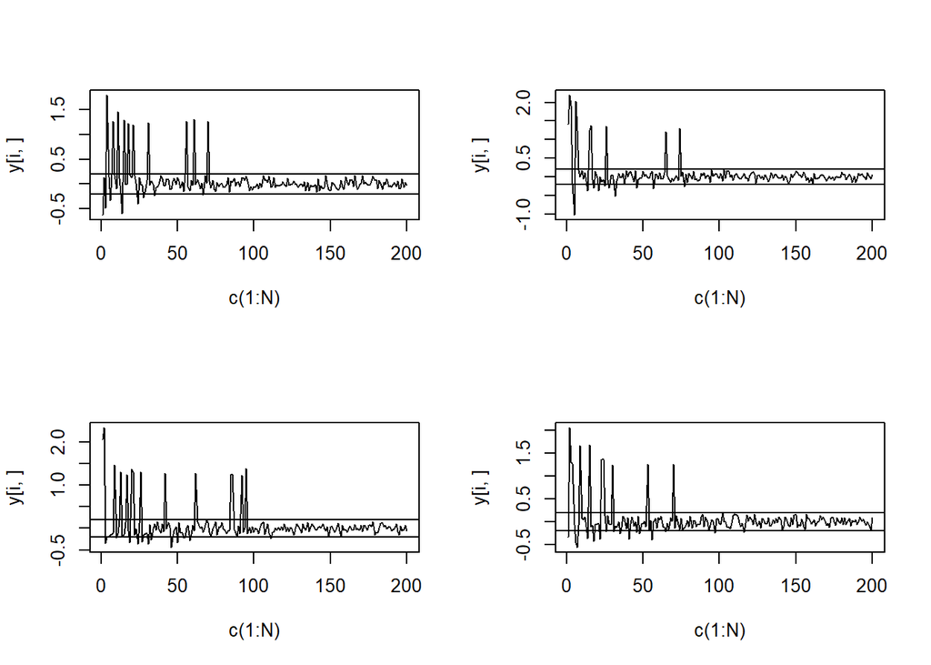

```r
set.seed(1)

N<-200
R<-10

y<-matrix(0,R,N)

for (j in 1:R) {
        for (i in 1:N) {
                x<-rnorm(n=1)/sqrt(i)
                if (x<0.2) {
                        y[j,i]<-x
                } else {
                        y[j,i]<-x+1
                }
        }
}

par(mfrow=c(2,2))
for (i in 1:4) {
        plot(c(1:N),type="l",y[i,])
        abline(h=0.2);abline(h=-0.2)
}
```

Como podemos ver, para as 4 realizações, todas convergiram para N>100. No entanto, essa conclusão não pode ser generalizada para qualquer realização, conforme resultado da simulação, envolvendo 10 realizações.

O que é possível concluir é que a probabilidade de convergência é alta, para valores grandes de N.

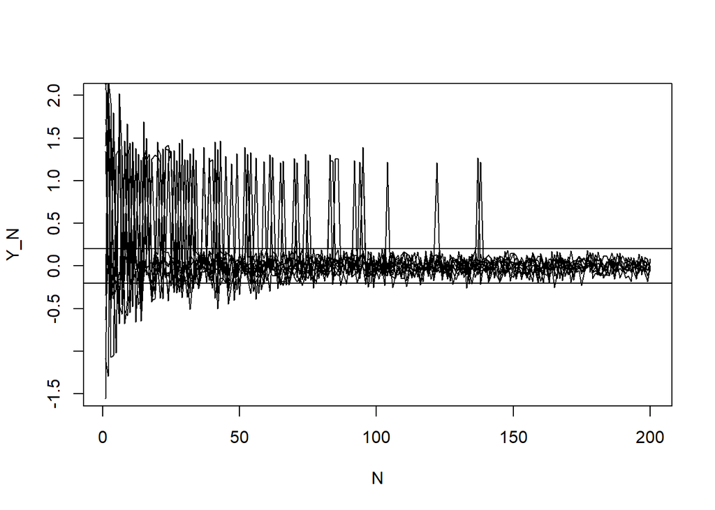

```r
plot(c(1:N),type="l",y[1,],xlab="N",ylab="Y_N",xlim=c(1, N),ylim=c(-1.5,2))
abline(h=0.2);abline(h=-0.2)

for (j in 2:R) {
        par(new=T)
        plot(y[j,],type='l',xlab="",ylab="",axes=F,xlim=c(1, N),ylim=c(-1.5,2))
}
```

## Exercício 15.9

Seja $S_N=\sum_{i=1}^{100}X_i$, em que $X_i$ é a VA resistência. De acordo com o Teorema do Limite Central, $S_N$ tem distribuição aproximadamente normal, com $E[S_N]=NE[X]=1000$ e $var(S_N)=Nvar(X_i)=200$.

Desta forma, a probabilidade da resitência dos 100 resistores conectados em série ser superior a 1030 é dada por:

$$\begin{gather}
P[S_N>1030]\approx Q(\frac{1030-1000}{\sqrt(200)})=0.0169
\end{gather}$$

# Exercício 15.12

A PDF de Y será aproximadamente normal, com média $E[Y]$ e variância $var(Y)$.

$$\begin{gather}
E[Y]=NE[X^2]=100(var(X)+E^2[X])=100.24=2400\\
\\
var(Y)=100.var(X^2)=100(E[X^2]-E^2[X^2])\\
\\
E[X^2]=24
\end{gather}$$

Para encontrar $E[X^4]$, define-se $Z\sim N(0,8)$, tal que $X=Z-4$. Desta forma,$E[X^4]=E[(Z-4)^4]$.

Desenvolvendo $E[(Z-4)^4]$ e sabendo que os momentos de ordem ímpar da pdf gaussiana com média 0 é igual a 0 e que o valor esperado de uma constante é igual a própria constante, temos que:

$$\begin{gather}
E[X^4]=E[(Z-4)^4=]=E[Z^4]+6E[V^2](-4)^2+(-4)^2=3var(Z)^2+96var(V)+256=1216
\end{gather}$$

## Exercício 15.14

A PDF de Y será aproximadamente normal, com média $E[Y]=10E[X]$ e variância $var(Y)=10var(X)$.

$$\begin{gather}
E[X]=\int_\infty^\infty xp(x)dx=\int_0^1 2x^2dx=\frac{2}{3}\\
E[X^2]=\int_\infty^\infty x^2p(x)dx=\int_0^1 2x^3dx=\frac{1}{2}\\
var(X)=E[X^2]-E^2[X]=\frac{1}{2}-(\frac{2}{3})^2=\frac{1}{18}
\end{gather}$$

Logo, $Y \sim N(\frac{20}{3},\frac{10}{18})$ e:

$$\begin{gather}
P(Y>7)=Q(\frac{7-\frac{20}{3}}{\sqrt(\frac{5}{9})})=0.3274
\end{gather}$$

## Exercício 15.17

A distribuição chi-quadrado é um caso especial da pdf gamma $\Gamma(\alpha,\beta)$, com $\alpha=\frac{v}{2}$ e $\beta=2\sigma^2$, em que $v$ é a quantidade de graus de liberdade (igual a $N$ nesse caso) e $\sigma$ o desvio padrão da distribuição normal que derivou a chi-quadrado que, no caso da distribuição normalizada, equivale a 1.

Ou seja, $Y_N \sim \Gamma(\frac{N}{2},2)$ e sua função característica é dada por:

$$\begin{gather}
\Phi_{Y_N}(w)=\frac{1}{(1-j\omega\beta)^\alpha}
\end{gather}$$

Substituindo $\alpha=\frac{N}{2}$ e $\beta=2$, temos que:

$$\begin{gather}
\Phi_{Y_N}(w)=\frac{1}{(1-2j\omega)^\frac{N}{2}}
\end{gather}$$

Definindo $Z_N=\frac{Y_N-E[Y_N]}{\sqrt{var(Y_N)}}$ e sabendo que $E[Y_N]=N$ e $var(Y_N)=2N$, temos que

$$\begin{gather}
Z_N=\frac{Y_N-N}{\sqrt{2N}}
\end{gather}$$

A função característica de $Z_N$ é dada por:

$$\begin{gather}
\Phi_{Z_N}(w)=E[e^{j\omega Z_N}]=E_{Y_N}[e^{j\omega \frac{Y_N-N}{\sqrt{2N}}}]\\
\end{gather}$$

Mas, separando $E_{Y_N}[e^{j\omega \frac{Y_N-N}{\sqrt{2N}}}]$ em seus dois termos, temos que:

$$\begin{gather}
E_{Y_N}[e^{j\frac{\omega}{\sqrt(2N)}Y_N}]=\Phi_{Y_N}(\frac{\omega}{\sqrt(2N)})=\frac{1}{(1-2j\frac{\omega}{\sqrt{2N}})^\frac{N}{2}}\\ \\
E_{Y_N}[e^{-j\omega \frac{N}{\sqrt{2N}}}]=e^{\frac{-j\omega N}{\sqrt{2N}}}=e^{-j\omega \sqrt{\frac{N^2}{2N}}}=e^{-j\omega \sqrt{\frac{N}{2}}}
\end{gather}$$

Logo:

$$\begin{gather}
\Phi_{Z_N}=\frac{e^{-j\omega \sqrt{\frac{N}{2}}}}{(1-2j\frac{\omega}{\sqrt{2N}})^\frac{N}{2}}
\end{gather}$$

Tirando o logaritmo de ambos os lados da equação, temos que:

$$\begin{gather}
\ln \Phi_{Z_N}=-j\omega \sqrt{\frac{N}{2}}-\frac{N}{2} \ln {(1-2j\frac{\omega}{\sqrt{2N}})}
\end{gather}$$

Com $N\rightarrow \infty$ e aplicando a aproximação dada no exercício, temos:

$$\begin{gather}
\ln \Phi_{Z_N}=-j\omega \sqrt{\frac{N}{2}}-\frac{N}{2}(-2j\frac{\omega}{\sqrt{2N}}-\frac{1}{2}(2j\frac{\omega}{\sqrt{2N}})^2)\\ \\
\ln \Phi_{Z_N}= -j\omega \sqrt{\frac{N}{2}}+j\omega \sqrt{\frac{N}{2}}+\frac{N}{4}(-\frac{2}{N}\omega^2)=-\frac{\omega^2}{2}
\end{gather}$$

Logo, $\Phi_{Z_N}=e^{-\frac{\omega^2}{2}}$ e, consequentemnete, $Z_N \sim N(0,1)$, C.Q.D..

## Exercício 15.24

```r
N<-1000
k1<-490
k2<-510

Y<-0

for (k in k1:k2) {
        lnpy=-N*log(2)

        for (i in (N-k+1):N) {
                lnpy=lnpy+log(i)
        }

        for (i in 1:k) {
                lnpy=lnpy-log(i)
        }

        Y<-Y+exp(lnpy)
}

print(Y)
```

```
## [1] 0.49334
```

O resultado encontrado é o mesmo dado pelo livro. Se o cálculo fosse feito diretamente para cada termo, o custo computacional e a complexidade do código seria bem maior.